# Companies House - EDA and Dataset Cleansing

```python
import pandas as pd
import numpy as np
import seaborn as sns
import matplotlib.pyplot as plt

# Path to the final dataset created in Script 1
final_path = r"C:\Users\AT355573\Documents\DS_Assignments\Companies House\data_processed\company_psc_dataset.parquet"

# Load the dataset
dataset = pd.read_parquet(final_path)

# Quick checks
print("Rows:", len(dataset))
print("Columns:", len(dataset.columns))

dataset.head()
```

```
Rows: 5677276
Columns: 13
```

|  | company_number | company_category | company_age_when_acc_due | accounts_category | industry | country_of_origin | registered_country | psc_count | has_corporate_psc | has_foreign_psc | has_sanctioned_psc | recent_psc_change | overdue |
| --- | --- | --- | --- | --- | --- | --- | --- | --- | --- | --- | --- | --- | --- |
| 0 | 08209948 | Private Limited Company | 13.798768 | DORMANT | 99999 - Dormant Company | United Kingdom | ENGLAND | 2 | 0 | 1 | 0 | 0 | 0 |
| 1 | 11743365 | Private Limited Company | 7.756331 | DORMANT | 59112 - Video production activities | United Kingdom | None | 1 | 0 | 0 | 0 | 0 | 0 |
| 2 | 16873705 | Private Limited Company | 1.746749 | NO ACCOUNTS FILED | 86210 - General medical practice activities | United Kingdom | UNITED KINGDOM | 1 | 0 | 0 | 0 | 1 | 0 |
| 3 | 15073164 | Private Limited Company | 3.378508 | TOTAL EXEMPTION FULL | 70229 - Management consultancy activities othe... | United Kingdom | ENGLAND | 1 | 0 | 1 | 0 | 0 | 0 |
| 4 | 13522064 | Private Limited Company | 5.774127 | MICRO ENTITY | 58290 - Other software publishing | United Kingdom | UNITED KINGDOM | 1 | 0 | 0 | 0 | 0 | 0 |

### Distribution of Target Variable

Check the distribution of the overdue flag, which is our target variable.

```python
# Check the distribution of the overdue flag
proportion_overdue = (
    dataset["overdue"]            # Select the overdue column (our target variable)
    .value_counts(normalize=True) # Calculate the proportion of each value rather than raw counts
    .rename("proportion")         # Rename the results column to be descriptive of its purpose
    .reset_index()                # Convert the Series into a data frame with two columns holding the overdue proportion values
    .style.hide(axis="index")     # Use pandas Styler to hide the default row numbers to display a cleaner table
)
proportion_overdue                # Display the table
```

| overdue | proportion |
| --- | --- |
| 0 | 0.920374 |
| 1 | 0.079626 |

This shows that approximately **~92%** of companies did not file late. Although **~8%** of companies filing late is small, it is still worth conducting this exercise (see main report for reasoning).

### Missing Values

Display Check how many entries within each variable are *null*.

```python
# Check the number of missing values in each column
null_counts = (
    dataset.isnull().sum()          # Count the number of missing (NaN) values per column
    .reset_index()                  # Convert the Series into a two‑column DataFrame
    .rename(columns={               # Rename the columns to meaningful, descriptive names
        "index": "column",
        0: "missing"
    })
    .style.hide(axis="index")       # Hide the default row numbers for a cleaner display
)
null_counts                          # Display the table
```

| column | missing |
| --- | --- |
| company_number | 0 |
| company_category | 0 |
| company_age_when_acc_due | 170582 |
| accounts_category | 0 |
| industry | 0 |
| country_of_origin | 0 |
| registered_country | 950019 |
| psc_count | 0 |
| has_corporate_psc | 0 |
| has_foreign_psc | 0 |
| has_sanctioned_psc | 0 |
| recent_psc_change | 0 |
| overdue | 0 |

- **"company_age_when_account_due"** shows **~171k** mising values. This is only a small proportion (**~3%**) of the overall population therefore, rather than complete these missing values with a manufactured value (for example **0**, or the mean/median value) they are to be removed at this point.
- **"registered_country"** shows **~950k** missing values, which is **~16.7%** of the population, this is too large of a percentage to remove at this stage, therefore the country will be imputed with **"UNKNOWN"**.

```python
# Drop rows where age is missing as this is only a small proportion of the overall population ~3%
dataset = dataset.dropna(subset=["company_age_when_acc_due"])

# Impute missing registered_country as "UNKNOWN"
dataset["registered_country"] = dataset["registered_country"].fillna("UNKNOWN")

# Quick checks
print("Rows:", len(dataset))
print("Columns:", len(dataset.columns))
```

```
Rows: 5506694
Columns: 13
```

```python
dataset.duplicated().sum()
```

```
np.int64(0)
```

## Categorical Column EDA

Below is a list of column types for the **11** remaining feature variables and the target variable *(overdue)*.

- **company_number** is a key idenfier which will be dropped prior to logistic regression modelling as it won't be needed.
- **5** of the feature variables are *object* type (we assume here non-numeric) and **6** feature varialbes are *float64* or *int64* (numeric types).

Let's explore the *object* variables *(company_category, accounts_category, industry, country_of_origin, registered_country)*. This exploration is focussed on determining whether the feature will add any meaningful predictive power to the logistic regression model or if it would simply add too much noise and confusion by its inclusion.

```python
dataset.dtypes.to_frame(name="data type")
```

|  | data type |
| --- | --- |
| company_number | object |
| company_category | object |
| company_age_when_acc_due | float64 |
| accounts_category | object |
| industry | object |
| country_of_origin | object |
| registered_country | object |
| psc_count | int64 |
| has_corporate_psc | int64 |
| has_foreign_psc | int64 |
| has_sanctioned_psc | int64 |
| recent_psc_change | int64 |
| overdue | int64 |

### 1. Country Of Origin

Country of origin may have an impact on filing behaviour due to language and administrative barriers and other factors, therefore it is worth investigating here.

Looking at the distribution of the country of origin, below, it is clear that all companies have the same country of origin (UK). As there is no variation in the contents it offers no predictive power and will be removed at this point.

```python
# Check the distribution of the country_of_origin
country_of_origin = (
    dataset["country_of_origin"]     # Select the country_of_origin column
    .value_counts()                  # Calculate the raw frequency of each country value
    .rename("country_of_origin")     # Rename the results column to clearly describe its contents
    .reset_index(name="count")       # Convert the Series into a two‑column DataFrame with country + count
    .style.hide(axis="index")        # Hide the default row numbers for a cleaner, more readable table
)
country_of_origin                    # Display the table
```

| country_of_origin | count |
| --- | --- |
| United Kingdom | 5506694 |

```python
# Remove the variable
dataset = dataset.drop(columns=["country_of_origin"])

# Quick checks
print("Rows:", len(dataset))
print("Columns:", len(dataset.columns))
```

```
Rows: 5506694
Columns: 12
```

### 2. Registered Country

The registered country is interesting to investigate as the companies have different legal juridictions based on their registered company with different filing cultures; administrative processes; enforcement behaviours which may be a risk factor for filing late.

```python
# Check the distribution of the registered_country
registered_country_dist = (
    dataset["registered_country"]    # Select the desired column
    .value_counts()                  # Calculate the raw frequency of each value
    .rename("registered_country")    # Rename the results column to clearly describe its contents
    .reset_index(name="count")       # Convert the Series into a two‑column DataFrame
)

# Hide the default row numbers for a cleaner table. Note: Hiding them outside of the earlier code chunks ensures the count
# remains numeric for future usage.
registered_country_dist.style.hide(axis="index")  # Hide the default row numbers for a cleaner, more readable table
```

| registered_country | count |
| --- | --- |
| ENGLAND | 2866874 |
| UNITED KINGDOM | 1463589 |
| UNKNOWN | 849367 |
| SCOTLAND | 183597 |
| WALES | 86556 |
| NORTHERN IRELAND | 56704 |
| UK | 3 |
| CYMRU | 3 |
| PO33 2TG | 1 |

These are all either UK based or UNKNOWN.

Three of these columns *UK, CYMRU, PO33 2TG* contain very low counts, which would leave the columns almost entirely zeroes during one-hot encoding, which will be needed to allow the logistic regression model to handle categorical data. One-hot encoding with this current setup would add too much noise to the model, therefore the decision here is to reduce the number of categories down replacing these values to allow the data to fit into one of the other registered_country values, then test the data further by looking at the percentage of the population held within each category:

- UK and UNITED KINDGOM = ENGLAND as CH often use this incorrectly
- CYMRU = WALES as that is using the Welsh language word for Wales,
- PO33 2TG = ENGLAND as it is a postcode on the Isle of White which is part of England.

```python
# Clean and standardise the registered_country column
dataset["registered_country"] = (
    dataset["registered_country"]      # Select the registered country column
    .replace({                         # Replace each appearance of key entries with a new entry
        "UNITED KINGDOM": "ENGLAND",   # Replace UNITED KINGDOM with England
        "UK": "ENGLAND",               # Replace shorthand UK with the same standard label
        "CYMRU": "WALES",              # Convert Welsh-language label to its English equivalent
        "PO33 2TG": "ENGLAND"          # Correct an invalid postcode entry with the country to which it belongs
    })
)

# Compute counts and percentages for registered_country
registered_country = (
    dataset["registered_country"]                     # Select the cleaned registered_country column
    .value_counts()                                   # Calculate the raw frequency of each country value
    .reset_index(name="count")                        # Convert the Series into a two‑column DataFrame with correct names
    .rename(columns={"index": "registered_country"})  # Rename the first column for clarity
)

# Add a percentage column
registered_country["percentage"] = (
    registered_country["count"] / registered_country["count"].sum()*100
)

# Format the table for clean display
registered_country.style.hide(axis="index")
```

| registered_country | count | percentage |
| --- | --- | --- |
| ENGLAND | 4330467 | 78.640052 |
| UNKNOWN | 849367 | 15.424264 |
| SCOTLAND | 183597 | 3.334069 |
| WALES | 86559 | 1.571887 |
| NORTHERN IRELAND | 56704 | 1.029729 |

This table shows that **~94% (79+15)** of the companies are either registered in England or UNKNOWN. As UNKNOWN could potentially contain mostly ENGLAND but be a situation where Companies House did not collect the information at the time and therefore it isn't included as ENGLAND within the dataset, then this could put ENGLAND close to 94% of the values in the variable, which could lead us to believe that there is not enough variation in the feature to warrant keeping it as it would not contribute meaningful predictive power. Rather than drop this column based on the high-level distribution of the data next investigate the variable against the late filing target variable. Calculate the late filing rate by registered country and investigate the likelihood of filing late based on the registered country.

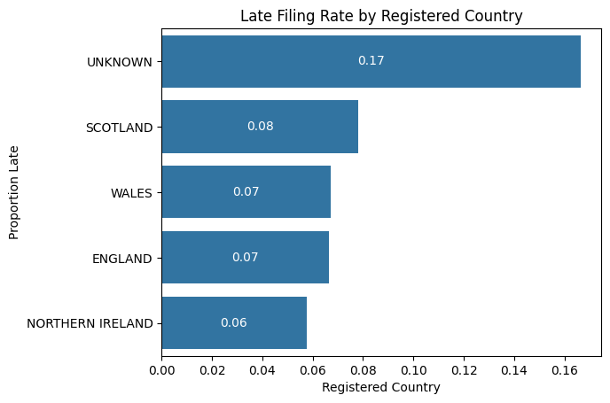

```python
# Calculate the late filing rate for each registered country
registered_country_late = (
    dataset.groupby("registered_country")["overdue"]  # Group the data by registered_country
    .mean()                                           # Calculate the mean
    .reset_index()                                    # Reset the index to return a tidy 2-column DataFrame
    .sort_values("overdue", ascending=False)          # Places the highest proportioned bar at the top.
)


# Plot the late filing rate by registered country
ax = sns.barplot(data=registered_country_late,
            x="overdue",                             # Plot the porportion late on the x-axis
            y="registered_country",                  # Plot the registered_country on the y-axis
            orient="h"                               # Fix the overlapping text by switching the axes.
           )

# Add labels at the end of each bar
ax.bar_label(    ax.containers[0],
    fmt="%.2f",            # ensures a decimal is used to 2d.p.
    label_type="center",   # places the label inside the bar
    color="white",         # makes the text white
    fontsize=10            # sets the font size
)

plt.title("Late Filing Rate by Registered Country")  # Add decriptive title
plt.ylabel("Proportion Late")                        # Add label to y-axis
plt.xlabel("Registered Country")                     # Add label to x-axis
plt.show()                                           # Display the plot
```

The bar chart shows shows whether a company is more likely to file late depending on its registered country.

- The plot indicates that companies where the country is **UNKNOWN** demonstrate a higher probability of filing late, roughly double/triple that compared to those where the registered country is known.
- All known countries are UK based, and demonstrate roughly the same probability of filing late.
- Even though 4 of the values are close in value, there is enough variation when considering the UNKNOWN category to suggest a potential predictive value and so this column will be retained for use in our logistic regression model.
- As there is a lot of noise from tiny differences between the UK categories these should be regrouped into "UNKNOWN" and "KNOWN UK" as this retains the strong signal (unknown) and removes the noise from tiny differences between 6-8% for the others, which makes the model more stable and interpretable.

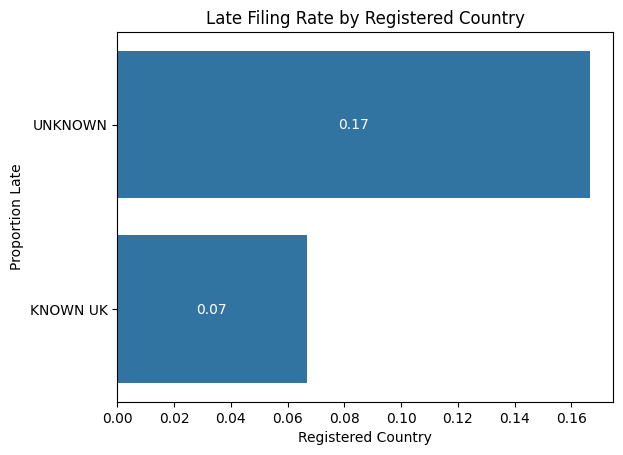

```python
# Clean and standardise the registered_country column
dataset["registered_country"] = (
    dataset["registered_country"]        # Select the registered country column
    .replace({                           # Replace each appearance of each known country with KNOWN UK
        "SCOTLAND": "KNOWN UK",
        "ENGLAND": "KNOWN UK",
        "WALES": "KNOWN UK",
        "NORTHERN IRELAND": "KNOWN UK"
    })
)


# Calculate the late filing rate for each registered country
registered_country_late = (
    dataset.groupby("registered_country")["overdue"]  # Group the data by registered_country
    .mean()                                           # Calculate the mean
    .reset_index()                                    # Reset the index to return a tidy 2-column DataFrame
    .sort_values("overdue", ascending=False)          # Places the highest proportioned bar at the top.
)


# Plot the late filing rate by registered country
ax = sns.barplot(data=registered_country_late,
            x="overdue",                             # Plot the porportion late on the x-axis
            y="registered_country",                  # Plot the registered_country on the y-axis
            orient="h"                               # Fix the overlapping text by switching the axes.
           )

# Add labels at the end of each bar
ax.bar_label(    ax.containers[0],
    fmt="%.2f",            # ensures a decimal is used to 2d.p.
    label_type="center",   # places the label inside the bar
    color="white",         # makes the text white
    fontsize=10            # sets the font size
)

plt.title("Late Filing Rate by Registered Country")  # Add decriptive title
plt.ylabel("Proportion Late")                        # Add label to y-axis
plt.xlabel("Registered Country")                     # Add label to x-axis
plt.show()                                           # Display the plot
```

The above chart displays why retaining this information was justified to preserve the prdictive signalling of the metric while reducing the sparsity of the one-hot coded values in the UK columns and improving model stability.

### 3. Company Category

The company category can often give an indication of size and accounting requirements that the company must meet, therefore this could be an important factor in determining lateness.

```python
# Check the distribution of the company_category
company_category_dist = (
    dataset["company_category"]      # Select the desired column
    .value_counts()                  # Calculate the raw frequency of each value
    .rename("company_category")      # Rename the results column to clearly describe its contents
    .reset_index(name="count")       # Convert the Series into a 2-column DataFrame
)

company_category_dist                # Print the results
```

|  | company_category | count |
| --- | --- | --- |
| 0 | Private Limited Company | 5251982 |
| 1 | PRI/LTD BY GUAR/NSC (Private, limited by guara... | 119735 |
| 2 | Limited Liability Partnership | 51280 |
| 3 | Community Interest Company | 42144 |
| 4 | PRI/LBG/NSC (Private, Limited by guarantee, no... | 36825 |
| 5 | Public Limited Company | 4681 |
| 6 | Old Public Company | 29 |
| 7 | PRIV LTD SECT. 30 (Private limited company, se... | 14 |
| 8 | Other Company Type | 3 |
| 9 | Converted/Closed | 1 |

The population is split across 10 categories, with a large proportion held within the *Private Limited Company* category. This would therefore leave a lot of columns containing almost entirely zeroes during one-hot encoding, which will be needed to allow the logistic regression model to handle categorical data. One-hot encoding with this current setup would add too much noise to the model, therefore the decision here is to reduce the number of categories down by mapping the category names to some grouped name labels.

```python
# Collect the categories into meaningful groupings to give fewer categories
company_category_mapping = {
    # Shorten the names of these and group small/missing categories into "OTHER".
    "Private Limited Company": "LTD",
    "Limited Liability Partnership": "LLP",
    "PRI/LTD BY GUAR/NSC (Private, limited by guarantee, no share capital)": "LTD BY GUARANTEE/CIC",
    "PRI/LBG/NSC (Private, Limited by guarantee, no share capital, use of 'Limited' exemption)": "LTD BY GUARANTEE/CIC",
    "Community Interest Company": "LTD BY GUARANTEE/CIC",
    "Public Limited Company": "PLC & OTHER",
    "Old Public Company": "PLC & OTHER",
    "PRIV LTD SECT. 30 (Private limited company, section 30 of the Companies Act)": "PLC & OTHER",
    "Other Company Type": "PLC & OTHER",
    "Converted/Closed": "PLC & OTHER"
}

dataset["company_category"] = (     # Replace the original company category column
    dataset["company_category"]     # Select the original column
    .map(company_category_mapping)  # map the new names into the column
)

# Compute counts and percentages for company_category
company_category = (
    dataset["company_category"]                     # Select the cleaned registered_country column
    .value_counts()                                 # Calculate the raw frequency of each country value
    .reset_index(name="count")                      # Convert the Series into a two‑column DataFrame with correct names
    .rename(columns={"index": "company_category"})  # Rename the first column for clarity
)

# Add a percentage column
company_category["percentage"] = (
    company_category["count"] / company_category["count"].sum()*100
)

# Format the table for clean display
company_category.style.hide(axis="index")
```

| company_category | count | percentage |
| --- | --- | --- |
| LTD | 5251982 | 95.374502 |
| LTD BY GUARANTEE/CIC | 198704 | 3.608408 |
| LLP | 51280 | 0.931230 |
| PLC & OTHER | 4728 | 0.085859 |

This table shows that **~95%** of the companies are **Private Limited Company (LTD)**. On the surface this value could be seen as showing not enough variation to be useful but using the same method as above we need to considering the lateness of the company and the variation involving the late filing rate by company category before deciding whether to drop it.

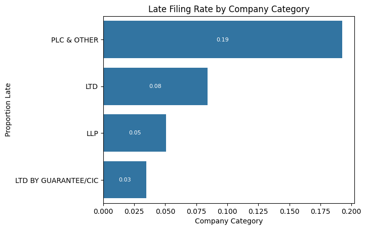

```python
# Calculate the late filing rate for each company category
company_category_late = (
    dataset.groupby("company_category")["overdue"]    # Group the data by company_category
    .mean()                                           # Calculate the mean
    .reset_index()                                    # Reset the index to return a tidy 2-column DataFrame
    .sort_values("overdue", ascending=False)          # Places the highest proportioned bar at the top.
)

# Plot the late filing rate by registered country
ax = sns.barplot(data=company_category_late,
            x="overdue",                             # Plot the porportion late on the x-axis
            y="company_category",                    # Plot the registered_country on the y-axis
            orient="h"                               # Fix the overlapping text by switching the axes.
           )

# Add labels at the end of each bar
ax.bar_label(    ax.containers[0],
    fmt="%.2f",            # ensures a decimal is used to 2d.p.
    label_type="center",   # places the label inside the bar
    color="white",         # makes the text white
    fontsize=8             # sets the font size
)


plt.title("Late Filing Rate by Company Category")  # Add decriptive title
plt.ylabel("Proportion Late")                      # Add label to y-axis
plt.xlabel("Company Category")                     # Add label to x-axis
plt.show()                                         # Display the plot
```

The late filing rate by company category graph above shows:

- **"PLC & OTHER"** companies demonstrate a higher probability of filing late compared to the other company category types.
- There is a big spread between **3%** and **19%** indicating a strong predictive signal.
- This is likley to produce strong coefficients in the logistic regression model and so will be retained as is.

### 4. Accounts Category

The accounts_category describes the type of annual accounts a company files, based on its size and exemptions. They do not describe different legal obligations, they just describes what they file, not when they file it.

Some preliminary decluttering of the data:

- **Total Exemption (SMALL/Full)** are used by companies that are legally exempt from filing full accounts. Including these in the data will artificially inflate the late filing rate and their lateness is not comparable to those that are legally obliged to file.
- **Filing Exemption Subsidiary** allows the subsidiary to file via their parent company's group accounts. They cannot be late as they have no filing obligation and their inclusion may skew the results.
- **Audit Exemption Subsidiary** relates to audit requirements rather than filing obligations, however subsidiary companies often use this exemption code when they consolidated their accounts via their parent company, therefore their own accounts may not exist in the dataset, and their inclusion may skew results.
- **Accounts Type Not Available** = Lateness could be more of a data quality/availability issue rather than a filing behaviour. This could include newly incorporated companies who are too new to have filed yet and dissolved companies who no longer have to file. Their characteristics should not be used to determine patterns in the data related to late filing as they may skew the findings.
- **Initial** = This could be a data quality/availability issue rather than a filing behaviour as the companies have not yet reached their first filing deadline, therefore they cannot be considered late or on-time yet. Including them will add bias to the data.
- **No Accounts Filed** = These are newly incorporated companies who's accounts are not yet due and there inclusion would skew the data and they cannot be considered either late or on-time yet.

**HEALTH WARNING: THE REMOVAL OF THESE ROWS WILL IMPACT ON THE FINDINGS ABOVE, THEREFORE LETS CONDUCT THE EDA ON WHETHER TO INCLUDE THE COLUMN BEFORE DROPPING ANY ROWS OF OUR POPULATION DATA.**

```python
# Create a filtered VIEW dataset for analysis only, being careful to not filter the original dataset
# Remove those where the accounts_category is in the unwanted list
accounts_category_filtered = dataset[
    ~dataset["accounts_category"].isin([
        "ACCOUNTS TYPE NOT AVAILABLE",
        "INITIAL",
        "NO ACCOUNTS FILED",
        "TOTAL EXEMPTION SMALL",
        "TOTAL EXEMPTION FULL",
        "AUDIT EXEMPTION SUBSIDIARY",
        "FILING EXEMPTION SUBSIDIARY"
    ])
].copy() # Adding copy in to ensure pandas treats this as a copy and not the original dataset
```

```python
# Compute counts and percentages for accounts_category
accounts_category_summary = (
    accounts_category_filtered["accounts_category"]  # Select the cleaned registered_country column
    .value_counts()                                  # Calculate the raw frequency of each country value
    .reset_index(name="count")                       # Convert the Series into a two‑column DataFrame with correct names
    .rename(columns={"index": "accounts_category"})  # Rename the first column for clarity
)

# Add a percentage column
accounts_category_summary["percentage"] = (
    accounts_category_summary["count"] / accounts_category_summary["count"].sum()*100
)

accounts_category_summary
```

|  | accounts_category | count | percentage |
| --- | --- | --- | --- |
| 0 | MICRO ENTITY | 1829713 | 64.239766 |
| 1 | DORMANT | 668992 | 23.487776 |
| 2 | UNAUDITED ABRIDGED | 164997 | 5.792913 |
| 3 | FULL | 81046 | 2.845461 |
| 4 | SMALL | 68879 | 2.418287 |
| 5 | GROUP | 27300 | 0.958481 |
| 6 | MEDIUM | 6072 | 0.213183 |
| 7 | AUDITED ABRIDGED | 1230 | 0.043184 |
| 8 | PARTIAL EXEMPTION | 27 | 0.000948 |

Nine categories remain, with **~93.5% (64.2+23.5+5.8)** of the data held in only 3 categories. Grouping these categories into fewer bandings based on their account filing type will remove some of the noise from sparsely populated one-hot coded columns in the groups with smaller percentages/counts. All of these accounts category types are legally bound to filing some form of accounts to differeng levels and therefore could be categorised into late/on-time depending on their filing behaviour held within the data.

```python
# Collect the categories into meaningful groupings to give fewer categories
accounts_category_mapping = {
    "FULL": "FULL",
    "MEDIUM": "FULL",
    "GROUP": "FULL",

    "SMALL": "REDUCED",
    "UNAUDITED ABRIDGED": "REDUCED",
    "AUDITED ABRIDGED": "REDUCED",
    "PARTIAL EXEMPTION": "REDUCED",

    "MICRO ENTITY": "SIMPLEST",

    # Dormant - these have simplified filing obligations
    # Being dormant doesn't mean not filing, they can still be fined for filing late.
    "DORMANT": "MINIMAL",
}

accounts_category_filtered["accounts_category_grouped"] = (
    accounts_category_filtered["accounts_category"]
    .map(accounts_category_mapping)
)
```

```python
# Compute counts and percentages for grouped accounts_category
accounts_category_summary = (
    accounts_category_filtered["accounts_category_grouped"]    # Select the cleaned registered_country column
    .value_counts()                                            # Calculate the raw frequency of each country value
    .reset_index(name="count")                                 # Convert the Series into a two‑column DataFrame with correct names
    .rename(columns={"index": "accounts_category_grouped"})    # Rename the first column for clarity
)

# Add a percentage column
accounts_category_summary["percentage"] = (
    accounts_category_summary["count"] /
    accounts_category_summary["count"]
    .sum()*100
)

accounts_category_summary
```

|  | accounts_category_grouped | count | percentage |
| --- | --- | --- | --- |
| 0 | SIMPLEST | 1829713 | 64.239766 |
| 1 | MINIMAL | 668992 | 23.487776 |
| 2 | REDUCED | 235133 | 8.255332 |
| 3 | FULL | 114418 | 4.017125 |

Here the data is now grouped into 4 account_category types. Next look at the late filing rate by accounts category to test for variation in the remaining data before deciding whether to retain the column and filter the data, or drop the column and retain the unfiltered dataset.

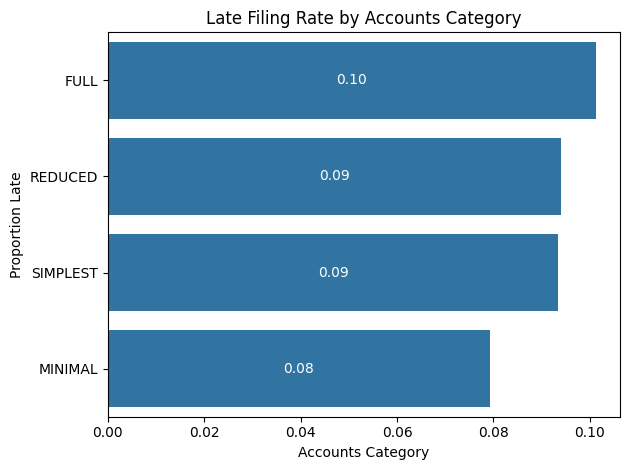

```python
# Calculate the late filing rate for each company category in the filtered dataset
accounts_category_late = (
    accounts_category_filtered.groupby("accounts_category_grouped")["overdue"]
    .mean()
    .reset_index()
    .sort_values("overdue", ascending=False) # Ensure the highest frequency is at the top
)

ax = sns.barplot(data=accounts_category_late,
            x="overdue",
            y="accounts_category_grouped",
            orient="h" # fixes the overlapping text by switching the axes.
           )

# Add labels at the end of each bar
ax.bar_label(
    ax.containers[0],
    fmt="%.2f",
    label_type="center",
    color="white"
)

plt.title("Late Filing Rate by Accounts Category")
plt.ylabel("Proportion Late")
plt.xlabel("Accounts Category")
plt.tight_layout()
plt.show()
```

This chart demonstrates minimal variation in the late filing rates for companies who legally have to file accounts therefore this column should be removed as it will have limited to no predictive power in the logistic regression model.

**HEALTH WARNING: AS THIS SECTION HAS POINTED OUT SOME COMPANIES LEGALLY DO NOT HAVE TO FILE ACCOUNTS THEREFORE THEY SHOULD HAVE BEEN REMOVED FROM THE POPULATION EARLIER AS THEY CANNOT BE CONSIDERED LATE OR ON-TIME. THIS MEANS THAT THE EARLIER EDA TESTING WILL NEED TO BE RE-RUN AFTER MOVING THIS SECTION ABOVE THEM AND RE-RUNNING THE CODE - THIS WILL BE CONDUCTED IN A SECOND ITERATION OF THIS PROJECT PRIOR TO FINAL SUBMISSION.**

**FOR NOW LETS CONTINUE SO THAT THE CODE IS WRITTEN FOR THE NEXT STEPS AND CAN BE EDITED LATER**

```python
# Remove the variable
dataset = dataset.drop(columns=["accounts_category"])

# Quick checks
print("Rows:", len(dataset))
print("Columns:", len(dataset.columns))
```

```
Rows: 5506694
Columns: 11
```

### 5. Industry (SIC)

Companies House [Nature of Business: Standard Industrial Classification (SIC) codes](https://resources.companieshouse.gov.uk/sic/) The industry variable features the SIC code followed by the SIC description.

Industry may affect filing behaviours due to a variety of reasons such as seaonality and workload cycles (retail sector), business stability and turnover (building trade) among many other reasons. It is worth investigating here.

```python
# Check the distribution of the industry
industry_dist = (
    dataset["industry"]              # Select the desired column
    .value_counts()                  # Calculate the raw frequency of each value
    .rename("industry")              # Rename the results column to clearly describe its contents
    .reset_index(name="count")       # Convert the Series into a 2-column DataFrame
)

industry_dist                        # Print the results
```

|  | industry | count |
| --- | --- | --- |
| 0 | 68209 - Other letting and operating of own or ... | 274652 |
| 1 | 68100 - Buying and selling of own real estate | 250226 |
| 2 | 70229 - Management consultancy activities othe... | 219502 |
| 3 | 82990 - Other business support service activit... | 187354 |
| 4 | 47910 - Retail sale via mail order houses or v... | 160041 |
| ... | ... | ... |
| 1157 | 6720 - Auxiliary insurance & pension fund | 1 |
| 1158 | 2465 - Manufacture of prepared unrecorded media | 1 |
| 1159 | 8022 - Technical & vocational secondary | 1 |
| 1160 | 2666 - Manufacture other articles of concrete,... | 1 |
| 1161 | 2231 - Reproduction of sound recording | 1 |

1162 rows × 2 columns

1162 different entries in the industry column will create far too many potentially sparsely populated columns when one-hot encoding the data for the logistic regression model. A condensed list will derive more meaningful analytics by categorising companies into higher level industries. To do this the first 2 characters of the variable are extracted which provides a means of assigning an industry like those seen that can be seen by [clicking this link](https://resources.companieshouse.gov.uk/sic/). (Note: Shortened descriptions have been used here)

```python
# Create the SIC Codes table
Sic_Codes = pd.DataFrame({
    "Code": ["01-03", "05-09", "10-33", "35", "36-39", "41-43", "45-47", "49-53", "55-56", "58-63",
             "64-66", "68", "69-75", "77-82", "84", "85", "86-88", "90-93", "94-96", "97-98", "99", np.nan],
    "Industry": [
        "Agriculture, Forestry & Fishing",
        "Mining & Quarrying",
        "Manufacturing",
        "Energy supply",
        "Water, Waste & Recycling",
        "Construction",
        "Wholesale & Retail",
        "Transport & Storage",
        "Accommodation & Food",
        "Information & Communication",
        "Finance & Insurance",
        "Real Estate",
        "Professional, Scientific & Tech",
        "Admin & Support Services",
        "Public Administration & Defence",
        "Education",
        "Health & Social Care",
        "Arts, Entertainment & Recreation",
        "Other Services",
        "Household Services",
        "Extraterritorial Organisations",
        "UNKNOWN"
    ]
})

Sic_Codes
```

|  | Code | Industry |
| --- | --- | --- |
| 0 | 01-03 | Agriculture, Forestry & Fishing |
| 1 | 05-09 | Mining & Quarrying |
| 2 | 10-33 | Manufacturing |
| 3 | 35 | Energy supply |
| 4 | 36-39 | Water, Waste & Recycling |
| 5 | 41-43 | Construction |
| 6 | 45-47 | Wholesale & Retail |
| 7 | 49-53 | Transport & Storage |
| 8 | 55-56 | Accommodation & Food |
| 9 | 58-63 | Information & Communication |
| 10 | 64-66 | Finance & Insurance |
| 11 | 68 | Real Estate |
| 12 | 69-75 | Professional, Scientific & Tech |
| 13 | 77-82 | Admin & Support Services |
| 14 | 84 | Public Administration & Defence |
| 15 | 85 | Education |
| 16 | 86-88 | Health & Social Care |
| 17 | 90-93 | Arts, Entertainment & Recreation |
| 18 | 94-96 | Other Services |
| 19 | 97-98 | Household Services |
| 20 | 99 | Extraterritorial Organisations |
| 21 | NaN | UNKNOWN |

```python
# Extract the first two digits from the industry string
dataset["sic_prefix"] = dataset["industry"].str[:2]

# Map SIC prefixes to short industry categories
def map_sic(prefix):
    # Primary & Utilities
    if prefix in ["01", "02", "03"]:
        return "Primary & Utilities"
    elif prefix in ["05", "06", "07", "08", "09"]:
        return "Primary & Utilities"
    elif prefix in ["35"]:
        return "Primary & Utilities"
    elif prefix in ["36", "37", "38", "39"]:
        return "Primary & Utilities"

    # Major standalone industries
    elif prefix in [f"{i:02d}" for i in range(10, 34)]:
        return "Manufacturing"
    elif prefix in ["41", "42", "43"]:
        return "Construction"
    elif prefix in ["45", "46", "47"]:
        return "Wholesale & Retail"
    elif prefix in ["49", "50", "51", "52", "53"]:
        return "Transport & Storage"
    elif prefix in ["55", "56"]:
        return "Accommodation & Food"
    elif prefix in ["58", "59", "60", "61", "62", "63"]:
        return "Information & Communication"
    elif prefix in ["64", "65", "66"]:
        return "Finance & Insurance"
    elif prefix == "68":
        return "Real Estate"
    elif prefix in ["69", "70", "71", "72", "73", "74", "75"]:
        return "Professional, Scientific & Tech"
    elif prefix in ["77", "78", "79", "80", "81", "82"]:
        return "Admin & Support Services"
    elif prefix in ["86", "87", "88"]:
        return "Health & Social Care"

    # Other Services (merged)
    elif prefix in ["90", "91", "92", "93", "94", "95", "96", "85", "97", "98"]:
        return "Other Services"

    # Public & Non‑Market
    elif prefix in ["84", "99"]:
        return "Public & Non‑Market"

    # Unknown
    else:
        return "UNKNOWN"


# Apply mapping of new categories into the original industry column.
dataset["industry"] = dataset["sic_prefix"].apply(map_sic)
# Drop sic_prefix because industry replaces it
dataset = dataset.drop(columns=["sic_prefix"])

dataset.head()
```

|  | company_number | company_category | company_age_when_acc_due | industry | registered_country | psc_count | has_corporate_psc | has_foreign_psc | has_sanctioned_psc | recent_psc_change | overdue |
| --- | --- | --- | --- | --- | --- | --- | --- | --- | --- | --- | --- |
| 0 | 08209948 | LTD | 13.798768 | Public & Non‑Market | KNOWN UK | 2 | 0 | 1 | 0 | 0 | 0 |
| 1 | 11743365 | LTD | 7.756331 | Information & Communication | UNKNOWN | 1 | 0 | 0 | 0 | 0 | 0 |
| 2 | 16873705 | LTD | 1.746749 | Health & Social Care | KNOWN UK | 1 | 0 | 0 | 0 | 1 | 0 |
| 3 | 15073164 | LTD | 3.378508 | Professional, Scientific & Tech | KNOWN UK | 1 | 0 | 1 | 0 | 0 | 0 |
| 4 | 13522064 | LTD | 5.774127 | Information & Communication | KNOWN UK | 1 | 0 | 0 | 0 | 0 | 0 |

```python
# Compute counts and percentages for industry
# Check the distribution of the industry
industry_dist = (
    dataset["industry"]                             # Select the desired column
    .value_counts()                                 # Calculate the raw frequency of each value
    .reset_index(name="count")                      # Convert the Series into a two‑column DataFrame with correct names
    .rename(columns={"index": "industry"})          # Rename the first column for clarity
)

# Add a percentage column
industry_dist["percentage"] = (
    industry_dist["count"] / industry_dist["count"].sum()*100
)

# Format the table for clean display
industry_dist.style.hide(axis="index")

industry_dist                        # Print the results
```

|  | industry | count | percentage |
| --- | --- | --- | --- |
| 0 | Wholesale & Retail | 747063 | 13.566452 |
| 1 | Professional, Scientific & Tech | 682445 | 12.393007 |
| 2 | Real Estate | 613759 | 11.145689 |
| 3 | Other Services | 609164 | 11.062245 |
| 4 | Construction | 568684 | 10.327140 |
| 5 | Information & Communication | 460494 | 8.362440 |
| 6 | Admin & Support Services | 402792 | 7.314588 |
| 7 | Accommodation & Food | 296747 | 5.388841 |
| 8 | Manufacturing | 238904 | 4.338429 |
| 9 | Health & Social Care | 231155 | 4.197709 |
| 10 | Finance & Insurance | 220803 | 4.009720 |
| 11 | Transport & Storage | 155887 | 2.830864 |
| 12 | Public & Non‑Market | 125806 | 2.284601 |
| 13 | Primary & Utilities | 88504 | 1.607208 |
| 14 | UNKNOWN | 64487 | 1.171066 |

On the surface this value appears to show enough variation to be useful but using the same method as above we need to consider the lateness of the company and the variation involving the late filing rate by industry to deciding whether to include it.

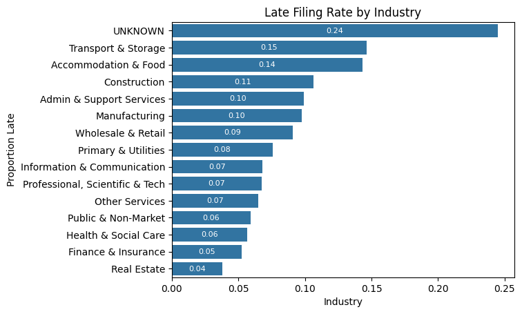

```python
# Calculate the late filing rate for each industry
industry_late = (
    dataset.groupby("industry")["overdue"]            # Group the data by industry
    .mean()                                           # Calculate the mean
    .reset_index()                                    # Reset the index to return a tidy 2-column DataFrame
    .sort_values("overdue", ascending=False)          # Places the highest proportioned bar at the top.
)

# Plot the late filing rate by industry
ax = sns.barplot(data=industry_late,
            x="overdue",                             # Plot the porportion late on the x-axis
            y="industry",                    # Plot the registered_country on the y-axis
            orient="h"                               # Fix the overlapping text by switching the axes.
           )

# Add labels at the end of each bar
ax.bar_label(    ax.containers[0],
    fmt="%.2f",            # ensures a decimal is used to 2d.p.
    label_type="center",   # places the label inside the bar
    color="white",         # makes the text white
    fontsize=8             # sets the font size
)


plt.title("Late Filing Rate by Industry")          # Add decriptive title
plt.ylabel("Proportion Late")                      # Add label to y-axis
plt.xlabel("Industry")                             # Add label to x-axis
plt.show()                                         # Display the plot
```

Late filing rates by industry vary substantially, with sectors such as *Transport & Storage, Accommodation & Food, and Construction" exhibiting high rates of late filing. This could reflect seasonal work peaks and lower levels of administrative professionalism. In contrast *Finance & Insurance and Real Estate* exhibit very low rates of late filing which could be due to those industries being bound by stricter compliance cultures within and greater reliance on solicotors and accountants

*UNKNOWN* contains the highest late filing rate which... **THIS SHOULD BE INVESTIGATED AGAIN AFTER THE SECTION ABOVE IS MOVED AND THE OTHER SECTIONS RE-RUN AS THESE MAY ALL DISAPPEAR**

Due to the distribution of this chart, industry will be retained beyond this point.

## Numeric Column EDA

Lets look at statistical descriptors for the numeric columns, to identify if any can be dropped here.

```python
dataset.describe(include=[np.number])
```

|  | company_age_when_acc_due | psc_count | has_corporate_psc | has_foreign_psc | has_sanctioned_psc | recent_psc_change | overdue |
| --- | --- | --- | --- | --- | --- | --- | --- |
| count | 5.506694e+06 | 5.506694e+06 | 5.506694e+06 | 5.506694e+06 | 5506694.0 | 5.506694e+06 | 5.506694e+06 |
| mean | 9.570700e+00 | 1.547011e+00 | 1.049717e-01 | 6.083285e-01 | 0.0 | 1.794095e-01 | 8.209227e-02 |
| std | 1.094047e+01 | 9.616788e-01 | 3.065170e-01 | 4.881239e-01 | 0.0 | 3.836948e-01 | 2.745053e-01 |
| min | 6.844627e-01 | 0.000000e+00 | 0.000000e+00 | 0.000000e+00 | 0.0 | 0.000000e+00 | 0.000000e+00 |
| 25% | 2.762491e+00 | 1.000000e+00 | 0.000000e+00 | 0.000000e+00 | 0.0 | 0.000000e+00 | 0.000000e+00 |
| 50% | 5.809719e+00 | 1.000000e+00 | 0.000000e+00 | 1.000000e+00 | 0.0 | 0.000000e+00 | 0.000000e+00 |
| 75% | 1.239425e+01 | 2.000000e+00 | 0.000000e+00 | 1.000000e+00 | 0.0 | 0.000000e+00 | 0.000000e+00 |
| max | 1.705051e+02 | 1.560000e+02 | 1.000000e+00 | 1.000000e+00 | 0.0 | 1.000000e+00 | 1.000000e+00 |

Looking at the information in this table above:

- **company_age_when_acc_due:** has a wide range **~0.7 to ~170 years** with a good variance and a strong potential relevance given by the assumption that older companies are more compliant than younger companies who perhaps are still learning the rules.
- **psc_count:** has a wide range **0-156** per company, has a good variance which gives a meaningful signal, perhaps due to those with higher psc_counts having more individuals for the accounts to pass through and therefore a higher level of complexity within the business than those with no or few PSCs.
- **has_corporate_psc:** this binary flag is **~10%** positive as shown in the mean **~1.05e-01 = 0.105** therefore this could be a useful compliance signal indicating that those with corporate PSCs are perhaps more scrupulous with their accounts, or more organised.
- **has_foreign_psc:** this binary flag is **~60%** positive as shown in the mean **~6.08e-01 = 0.608** therefore this could be a useful predictor given that cross-border behaviours may affect compliance.
- **has_sanctioned_psc:** shows that no company has a sanctioned person of significant control all values are **0.0** except for the count so this column shall be dropped from here as it adds no value to the logistic model, only noise.
- **recent_psc_change:** this binary flag **~18%** positive as shown in the mean **~1.79e-01 = 0.179** therefore this could be a useful behavioural driver indicating business instabaility due to governance changes.

One variable is dropped here and the others are retained.

```python
# Remove the unrequired column
dataset = dataset.drop(columns=["has_sanctioned_psc"])

# Quick checks
print("Rows:", len(dataset))
print("Columns:", len(dataset.columns))
```

```
Rows: 5506694
Columns: 10
```

### PSC Count Distribution

The other PSC columns are binary, but this one is not. Now we check the distribution of the PSC count across the companies to determin whether or not this data exhibits skew, as logistic regression is reliant on a linear relationship.

Use a column chart to display the distrubution as the PSC count is discrete not continuous.

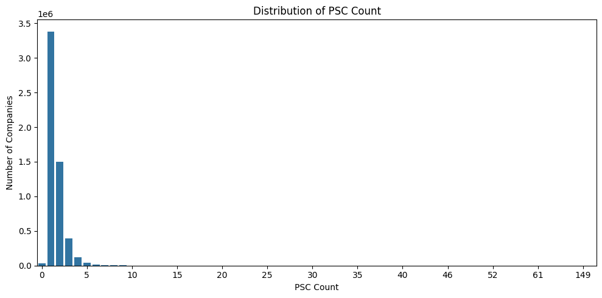

```python
# Visualise the distribution of PSC count
psc_dist = (
    dataset["psc_count"]                     # Select the PSC count column
    .value_counts()                          # Calculate the raw frequency of each PSC count value
    .sort_index()                            # Ensure PSC counts appear in numeric order (0, 1, 2, ...)
    .reset_index(name="count")               # Convert the Series into a 2‑column DataFrame
    .rename(columns={"index": "psc_count"})  # Rename the first column for clarity
)

import matplotlib.ticker as mtick            # import ticker from matplotlib to format the axis ticks better on the graph.

# Create a bar chart to show the distribution
plt.figure(figsize=(10, 5))
sns.barplot(
    data=psc_dist,                       # Use the prepared frequency table
    x="psc_count",                       # PSC count values (0, 1, 2, ...)
    y="count"                            # Number of companies for each PSC count
)

plt.gca().xaxis.set_major_locator(mtick.MultipleLocator(5))   # ticks every 5


# Add clear labels and layout adjustments
plt.title("Distribution of PSC Count")
plt.xlabel("PSC Count")
plt.ylabel("Number of Companies")
plt.tight_layout()                       # Prevent label cut‑off

plt.show()                               # Display the plot
```

**Health Warning:** The x-axis on the graph is affected by the way matplotlib condenses the axes when data becomes sparse, like at the upper end of the PSC count in this case, but it is still usable for the purposes of this analysis.

- **0 PSC** is present in the data could be due to corporate structure or where information is incomplete.
- **1 PSC** is the most common structure by a large amount, this is typical for small private companies with one single controlling director.
- **2 PSC** is the second most common structure, which show 2-director companies, sometimes with familial relationships (father/son, spouse).
- **3 PSC** third most common but much less frequent than 1 and 2 director companies. 3 or more starts to resemble more complex ownership/governance structures.
- **10+ PSC** are barely visible on the chart but exist in a rarer fruequency than the others.

This data is highly right-skewed and shows a meaningful variation in the governance complexity of companies within the population, therefore inferring that the variable will have important predictive value. The decision here is to cap the number of PSCs per company to attempt to prevent the long right tail of the distrubution (where outliers exist) from causing issues in the modelling, as logistic regression assumes a roughly linear relationship between the predictor and the log-odds.

The table below shows the final chosen capped value of **15 PSCs**. This was chosen to avoid inflating the value of **10+** so that it became much larger than **9 PSCs**, and to preserve some of the variation in values.

```python
# Cap the PSC count so that all values above 15 become 15
dataset["psc_count"] = (
    dataset["psc_count"]
    .clip(upper=15)                     # Apply an upper limit to the PSC count
)

# Check the distribution of the capped PSC count
psc_counts = (
    dataset["psc_count"]                     # Select the PSC count column (now capped)
    .value_counts()                          # Calculate the frequency of each PSC count value
    .reset_index(name="count")               # Convert the Series into a 2‑column DataFrame
    .rename(columns={"index": "psc_count"})  # Rename the first column for clarity
    .sort_values(by="psc_count")             # Sort the results in ascending PSC count order
)

psc_counts.head(16)                          # Display the head of the table to include the capped value
```

|  | psc_count | count |
| --- | --- | --- |
| 5 | 0 | 35273 |
| 0 | 1 | 3382958 |
| 1 | 2 | 1496330 |
| 2 | 3 | 388691 |
| 3 | 4 | 124187 |
| 4 | 5 | 44341 |
| 6 | 6 | 17848 |
| 7 | 7 | 7648 |
| 8 | 8 | 3826 |
| 9 | 9 | 1956 |
| 10 | 10 | 1133 |
| 12 | 11 | 707 |
| 13 | 12 | 431 |
| 14 | 13 | 318 |
| 15 | 14 | 203 |
| 11 | 15 | 844 |

PSC count still remains a numeric predictor after capping, the engineering only restricted the upper range of the values so that it reduced the influence of outliers. The variable can still be tested for multicolinearity with the rest of the numeric variables.

Now let's test the PSC count againts the late filing rate to establish whether the variable is worth keeping in the model.

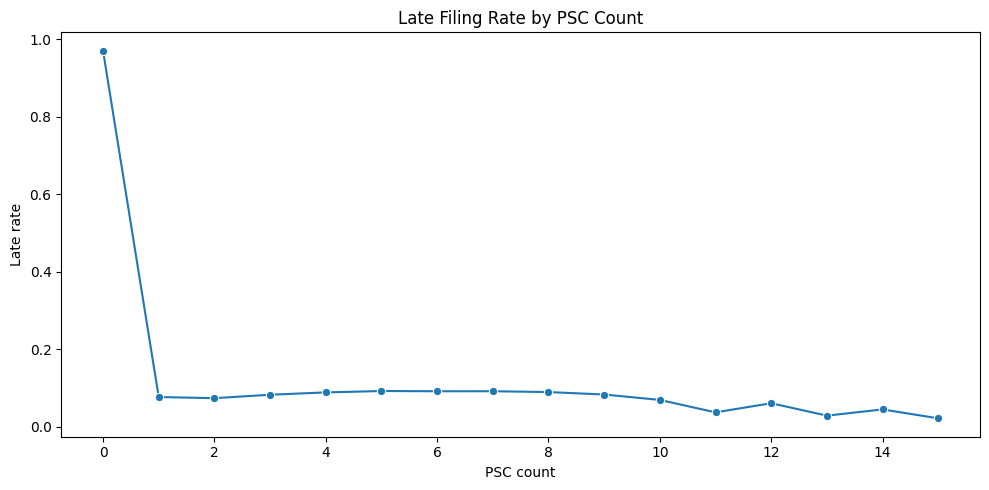

```python
# Calculate late rate by PSC count
psc_late_rate = (
    dataset.groupby("psc_count", observed=True)["overdue"]
    .mean()
    .reset_index(name="late_rate")
)

# Plot PSC count vs late rate
plt.figure(figsize=(10, 5))

sns.lineplot(
    data=psc_late_rate,
    x="psc_count",
    y="late_rate",
    marker="o"
)

plt.title("Late Filing Rate by PSC Count")
plt.xlabel("PSC count")
plt.ylabel("Late rate")
plt.tight_layout()
plt.show()
```

The late filing rate when companies have no PSCs is very high (close to **1**), with a huge drop when companies have **1 PSC**. From **2-10 PSCs** the rate seems relatively stable then it starts to get more unstable from **11 PSCs** onwards. This graph shows enough variability in the data to retain the column for the logistic regression modelling. It shows that companies with no PSC are more likely to file late than those with 1 or more PSC, this type of information works well in logistic regression models.

## Company Age When Account Due

- The minimum age is **~0.7 years** (see above) which demonstrates the age of new companies when their first accounts are likely to be due.
- No companies have a zero or negative age when their first accounts are due, which would suggest an issue in the data if that occurred.
- There are no missing values (see above checks for missing values)
- The maximum age is **~170 years** (see above) which is plausible given there may be old banks/railway companies etc in the data.

Given the wide range of data there may be outliers so lets check the distribution shape using a histogram. A historgram is used here as the data is continuous rather than discrete, the measure is calculated using the number of days from incorporation date to the account due date.

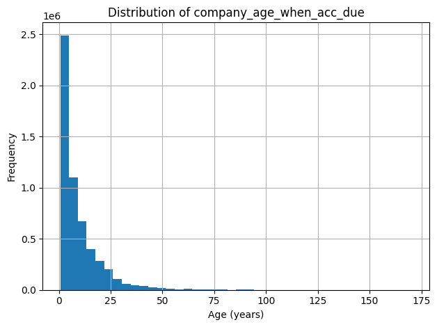

```python
%matplotlib inline
import matplotlib.pyplot as plt

# Visualise the distribution of company_age_when_acc_due
(
    dataset["company_age_when_acc_due"]     # Select the company age column
    .hist(bins=40)                          # Plot a histogram with 40 bins to show the distribution
)

# Add clear labels and a title for readability
plt.title("Distribution of company_age_when_acc_due")
plt.xlabel("Age (years)")
plt.ylabel("Frequency")
plt.tight_layout()                          # Prevent label cut-off in the final figure

plt.show()                                  # Display the plot
```

This distibution shows a right-skew, columns peaking high on the left with a long tail to the right. Most companies are young with fewer older companies tailing off to some very old companies.

Logistic regression assumes a linear relationship between each numeric feature and the log-odds of the target, right skew violates that assumpton, and may lead to unstable coefficients and a drop in performance.

To test whether to cap the ages or group the ages into bins, lets look at the company_age_when_acc_due against the late-filing rate.

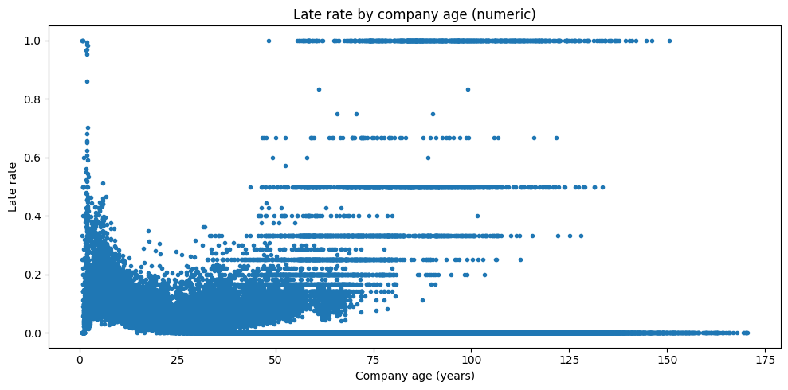

```python
# Calculate the late-filing rate for each company age value
age_late_rate = (
    dataset[["company_age_when_acc_due", "overdue"]]   # Select the relevant columns
    .groupby("company_age_when_acc_due")               # Group by company age
    .mean(numeric_only=True)                           # Calculate the mean late rate for each age
    .rename(columns={"overdue": "late_rate"})          # Rename the column for clarity
    .reset_index()                                     # Convert the index back into a column
)

# Plot late rate against numeric company age
plt.figure(figsize=(10, 5))

plt.plot(
    age_late_rate["company_age_when_acc_due"],   # X-axis: numeric age
    age_late_rate["late_rate"],                  # Y-axis: late rate
    marker="o",                                  # Small markers to show volatility
    linestyle="none",                            # No connecting line (too noisy)
    markersize=3,                                # Keep markers small for readability
)

plt.title("Late rate by company age (numeric)")
plt.xlabel("Company age (years)")
plt.ylabel("Late rate")
plt.tight_layout()

plt.show()
```

This plot shows that the company age when the accounts are due has an unstable relationship with the mean late rate for each age. There are large fluctuations caused by having high granularity in the age data. There is no smooth trend to the data.

Due to the granularity of the data and the lack of linear trend we pre-process this feature before it can be used in the logistic regression modelling steps by collecting the ages into *"bins"* rather than capping the tail like with PSC count. This then can be used much like the categorical variables with one-hot encoding of the bins during the logistic regression model.

To deal with the strong right-skew in the distribution and the large number of companies with low ages, we choose narrower bins for lower aged companies and wider bins as company ages increase, this allows for the upper bins to capture more companies and thus accommodates the long tail.

The age bins below are generated to reflect realistic real-world age group categories for company demographics.

- (0-2) New companies
- (2-5) Young but more established
- (5-10) mid-range age
- (10-20) mature companies
- (20+) long-standing companies

Let's place the companies into age bins and then conduct the same analysis as for the categorical variables above:

- Observe the percentages within each bin
- Plot the bins against the late filing rate and check for variability within the data.

```python
# Place the values into meaningful categorical bins, allowing outliers to be dealt with in the upper level grouping.
dataset["company_age_when_acc_due"] = pd.cut(
    dataset["company_age_when_acc_due"],
    bins=[0, 2, 5, 10, 20, 200],
    labels=["0–2", "2–5", "5–10", "10–20", "20+"],
    include_lowest=True
)


# Compute counts and percentages for company_age_when_acc_due
company_age_when_acc_due_dist = (
    dataset["company_age_when_acc_due"]                     # Select the cleaned column
    .value_counts()                                         # Calculate the raw frequency of each value
    .reset_index(name="count")                              # Convert the Series into a two‑column DataFrame
    .rename(columns={"index": "company_age_when_acc_due"})  # Rename the first column for clarity
    .sort_values(by="company_age_when_acc_due")             # Sort by the categorical order, not by count
)

# Add a percentage column
company_age_when_acc_due_dist["percentage"] = (
    company_age_when_acc_due_dist["count"]
    / company_age_when_acc_due_dist["count"].sum() * 100
)

company_age_when_acc_due_dist
```

|  | company_age_when_acc_due | count | percentage |
| --- | --- | --- | --- |
| 1 | 0–2 | 1268182 | 23.029825 |
| 2 | 2–5 | 1231216 | 22.358533 |
| 0 | 5–10 | 1271352 | 23.087391 |
| 3 | 10–20 | 1074945 | 19.520696 |
| 4 | 20+ | 660999 | 12.003554 |

This table shows a good spread of ages across the bins, but are these categories still considered meaningul to the model? Let's check by calculating the late filing rate by and displaying visually.

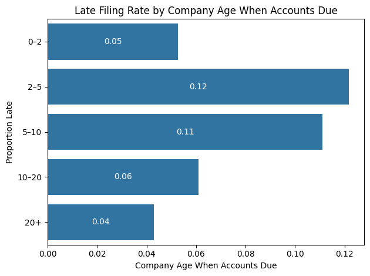

```python
# Calculate the late filing rate for each newly generated company age when acc due value
company_age_late = (
    dataset.groupby("company_age_when_acc_due", observed=True)["overdue"]
    .mean()
    .reset_index()
    .sort_values("overdue", ascending=False) # Ensure the highest frequency is at the top
)

ax = sns.barplot(data=company_age_late,
            x="overdue",
            y="company_age_when_acc_due",
            orient="h" # fixes the overlapping text by switching the axes.
           )

# Add labels at the end of each bar
ax.bar_label(
    ax.containers[0],
    fmt="%.2f",
    label_type="center",
    color="white"
)


plt.title("Late Filing Rate by Company Age When Accounts Due")
plt.ylabel("Proportion Late")
plt.xlabel("Company Age When Accounts Due")
plt.tight_layout()
plt.show()
```

These bins are acceptable, not too few or too many to be meaningful to the model and used as predictors. The variability between bars is clear and meaningful, with **3** groupings **~5%** and **2** groupings over double that. Given these values and the real-world meaning of the labelling of these categories this column will be retained as it now stands.

## Data Column Checks and Type Edits

Now we can removing **"company_number"** as it is not a predictor variable, then ensure that all columns are stored in the correct data types needed for the next stages of the model.

```python
# Remove the unrequired columns
dataset = dataset.drop(columns=["company_number"])

# Quick checks
print("Rows:", len(dataset))
print("Columns:", len(dataset.columns))

dataset.dtypes.to_frame(name="data type")
```

```
Rows: 5506694
Columns: 9
```

|  | data type |
| --- | --- |
| company_category | object |
| company_age_when_acc_due | category |
| industry | object |
| registered_country | object |
| psc_count | int64 |
| has_corporate_psc | int64 |
| has_foreign_psc | int64 |
| recent_psc_change | int64 |
| overdue | int64 |

```python
# Ensure each variable is stored as the correct type.
# Category for the categorical values, int64 for the numberic variables and int8 for the logical variables
dataset["company_category"] = dataset["company_category"].astype("category")
dataset["company_age_when_acc_due"] = dataset["company_age_when_acc_due"].astype("category")
dataset["industry"] = dataset["industry"].astype("category")
dataset["psc_count"] = dataset["psc_count"].astype("int64")
dataset["has_corporate_psc"] = dataset["has_corporate_psc"].astype("int8")
dataset["has_foreign_psc"] = dataset["has_foreign_psc"].astype("int8")
dataset["recent_psc_change"] = dataset["recent_psc_change"].astype("int8")
dataset["overdue"] = dataset["overdue"].astype("int8")

dataset.dtypes.to_frame(name="dtype")
```

|  | dtype |
| --- | --- |
| company_category | category |
| company_age_when_acc_due | category |
| industry | category |
| registered_country | object |
| psc_count | int64 |
| has_corporate_psc | int8 |
| has_foreign_psc | int8 |
| recent_psc_change | int8 |
| overdue | int8 |

## Multicollinearity

After deciding on the and cleaning our dataset columns now lets check to ensure there is no multicollinearity present and if any is present decide which to retain, which to remove or justify the retention of them both/all.

- Numeric vs Numeric
- Categorical vs Categorical
- Numeric vs Categorical

### Numeric vs Numeric

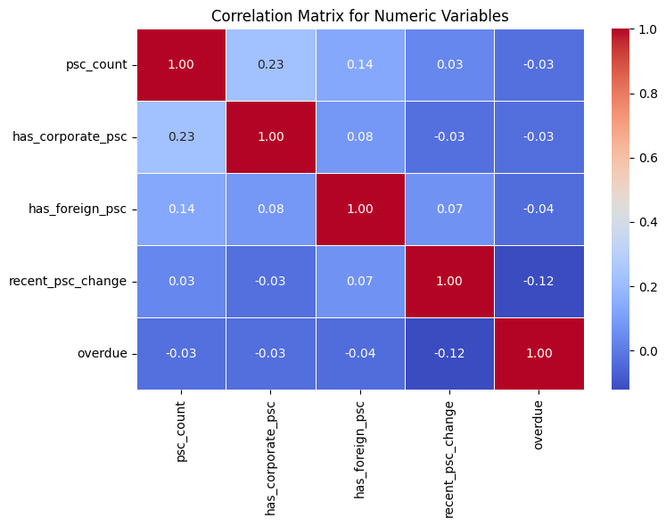

```python
# Gather only the numeric columns.
numeric_df = dataset.select_dtypes(include="number") # Can remove this and add in the one-hot encoding later.

corr_matrix = numeric_df.corr()
corr_matrix

# Visualise it with seaborn
plt.figure(figsize=(8, 6))
sns.heatmap(
    corr_matrix,
    annot=True,
    fmt=".2f",
    cmap="coolwarm",
    linewidths=0.5
)
plt.title("Correlation Matrix for Numeric Variables")
plt.tight_layout()
plt.show()
```

No two column pairs show correlation anywhere near to **+/-0.8** therefore all numeric columns are safe to keep here as they do not display multicolinearity with each other, there appears to be no duplicated information.

- The PSC count column is independent to the other variables.
- The boolean psc flags are also independent.
- Overdue is not strongly correlated with any single numeric PSC variable, which fits with using logistic regression as that does not require a linear/highly-correlated relationship between the target and predictor variables.

To double check this let's run VIF (Variance Inflation Factor on the numeric predictors.

```python
from statsmodels.stats.outliers_influence import variance_inflation_factor

X = dataset[["psc_count", "has_corporate_psc", "has_foreign_psc", "recent_psc_change"]]

vif = pd.DataFrame()
vif["feature"] = X.columns
vif["VIF"] = [variance_inflation_factor(X.values, i) for i in range(X.shape[1])]
vif
```

|  | feature | VIF |
| --- | --- | --- |
| 0 | psc_count | 2.250734 |
| 1 | has_corporate_psc | 1.182317 |
| 2 | has_foreign_psc | 2.080332 |
| 3 | recent_psc_change | 1.197119 |

All variables have VIF < 5 therefore all variables can be retained at this point.

### Category vs Category

Use Cramer's V to check whether two categorical variables are strongly associated.

```python
import scipy.stats as ss

def cramers_v(x, y):
    """Calculate bias-corrected Cramér's V for two categorical variables."""
    confusion = pd.crosstab(x, y)
    chi2 = ss.chi2_contingency(confusion)[0]
    n = confusion.sum().sum()
    phi2 = chi2 / n
    r, k = confusion.shape

    # Bias correction
    phi2_corr = max(0, phi2 - ((k-1)*(r-1))/(n-1))
    r_corr = r - ((r-1)**2)/(n-1)
    k_corr = k - ((k-1)**2)/(n-1)

    return np.sqrt(phi2_corr / min((k_corr-1), (r_corr-1)))
```

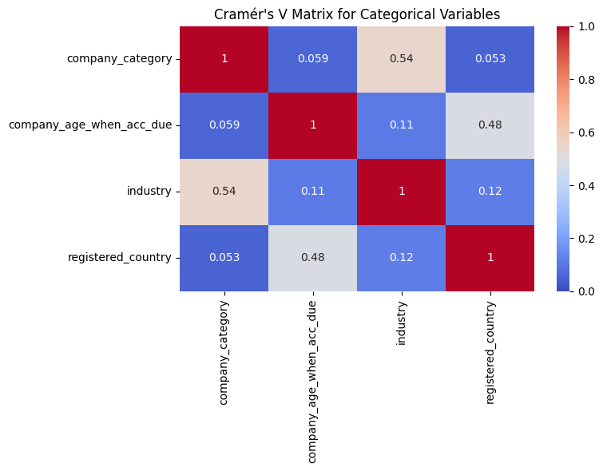

```python
categorical_cols = [
    "company_category",
    "company_age_when_acc_due",
    "industry",
    "registered_country"
]

cramers_matrix = pd.DataFrame(
    np.zeros((len(categorical_cols), len(categorical_cols))),
    index=categorical_cols,
    columns=categorical_cols
)

for col1 in categorical_cols:
    for col2 in categorical_cols:
        cramers_matrix.loc[col1, col2] = cramers_v(dataset[col1], dataset[col2])

plt.figure(figsize=(8, 6))
sns.heatmap(cramers_matrix, annot=True, cmap="coolwarm", vmin=0, vmax=1)
plt.title("Cramér's V Matrix for Categorical Variables")
plt.tight_layout()
plt.show()
```

This matrix shows the following:

- industry and company_category are strongly associated as they have Cramer's V **> 50**
- registered_country and company_age_when_acc_due are somewhat strongly associated as they have Cramer's V between **0.3-0.5**
- Weak or no meaningful association between the rest.

### Numeric vs Category - Correlation Ration (eta-squared)

This measures how much variance in a numeric variable is explained by a categorical variable.

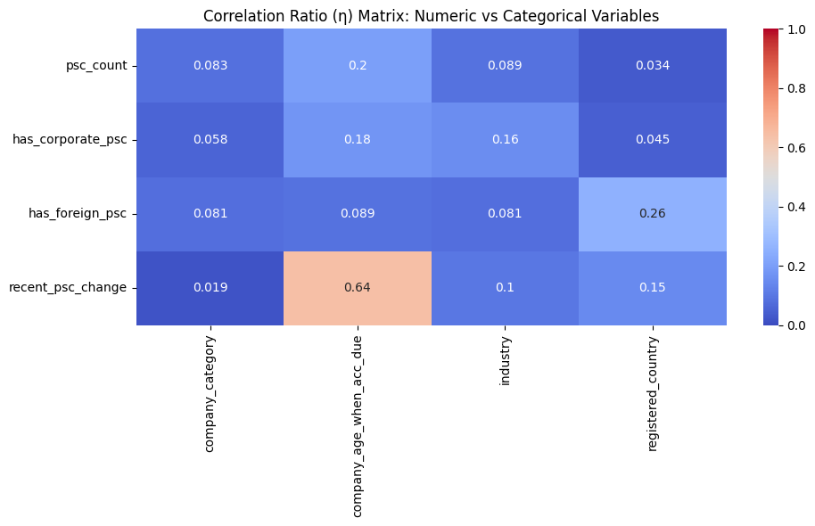

```python
# 1. FAST CORRELATION RATIO (η) FUNCTION

def fast_eta(categories, values):
    """
    Fast, vectorised correlation ratio (η) for numeric vs categorical.
    Measures how much variance in a numeric variable is explained by a categorical variable.
    """
    categories = pd.Series(categories)
    values = pd.Series(values)

    grand_mean = values.mean()

    # Group means and counts (explicit observed=False to silence warning)
    group_stats = values.groupby(categories, observed=False).agg(['mean', 'count'])

    ss_between = (group_stats['count'] * (group_stats['mean'] - grand_mean)**2).sum()
    ss_total = ((values - grand_mean)**2).sum()

    return np.sqrt(ss_between / ss_total)


# 2. DEFINE VARIABLE GROUPS
numeric_cols = ["psc_count", "has_corporate_psc", "has_foreign_psc", "recent_psc_change"]
categorical_cols = ["company_category", "company_age_when_acc_due", "industry", "registered_country"]


# 3. BUILD η MATRIX
eta_matrix = pd.DataFrame(index=numeric_cols, columns=categorical_cols, dtype=float)

for num in numeric_cols:
    for cat in categorical_cols:
        eta_matrix.loc[num, cat] = fast_eta(dataset[cat], dataset[num])


# 4. VISUALISE η MATRIX
plt.figure(figsize=(10, 6))
sns.heatmap(
    eta_matrix.astype(float),
    annot=True,
    cmap="coolwarm",
    vmin=0,
    vmax=1
)
plt.title("Correlation Ratio (η) Matrix: Numeric vs Categorical Variables")
plt.tight_layout()
plt.show()
```

The heatmap displays that:

- The numeric PSC variables are not explained by the categorical variables as shown by the blue colouring in the visual.
- **has_foreign_psc** vs **registered_country** has a moderate relationship at **0.26** however foreing PSCs should be more expected in companies registered outside of the UK. Both variables measure different things, and this is a real structural relationship, therefore these columns should not be dropped here.
- **recent_psc_change** vs **company_age_when_acc_due** has a strong relationshop at **0.64**. This has an explainable real world justification as older companies tend to have more stable ownership. But this does not indicate multicollinearity/data redundancy, it measures association not linear dependence.
- This matrix presents no evidence of any problematic-numeric to categorical multicollinearity.

```python
from numpy.linalg import inv

def fast_vif(df):
    """
    Efficient VIF calculation using matrix algebra.
    Much faster than statsmodels for large dummy matrices.
    """
    X = np.asarray(df)
    XTX_inv = inv(np.corrcoef(X, rowvar=False))
    return pd.Series(np.diag(XTX_inv), index=df.columns, name="VIF")

# Run fast VIF
vif_df = fast_vif(X).sort_values(ascending=False)
vif_df
```

```
psc_count            1.071677
has_corporate_psc    1.059545
has_foreign_psc      1.025870
recent_psc_change    1.006621
Name: VIF, dtype: float64
```

## Final Data Set Contruction

```python
# Display top 20 rows of the final dataset
dataset.head(10)
```

|  | company_category | company_age_when_acc_due | industry | registered_country | psc_count | has_corporate_psc | has_foreign_psc | recent_psc_change | overdue |
| --- | --- | --- | --- | --- | --- | --- | --- | --- | --- |
| 0 | LTD | 10–20 | Public & Non‑Market | KNOWN UK | 2 | 0 | 1 | 0 | 0 |
| 1 | LTD | 5–10 | Information & Communication | UNKNOWN | 1 | 0 | 0 | 0 | 0 |
| 2 | LTD | 0–2 | Health & Social Care | KNOWN UK | 1 | 0 | 0 | 1 | 0 |
| 3 | LTD | 2–5 | Professional, Scientific & Tech | KNOWN UK | 1 | 0 | 1 | 0 | 0 |
| 4 | LTD | 5–10 | Information & Communication | KNOWN UK | 1 | 0 | 0 | 0 | 0 |
| 5 | LTD | 5–10 | Information & Communication | KNOWN UK | 1 | 0 | 1 | 0 | 0 |
| 6 | LTD | 5–10 | Real Estate | KNOWN UK | 2 | 0 | 1 | 0 | 0 |
| 7 | LTD | 10–20 | Professional, Scientific & Tech | KNOWN UK | 3 | 0 | 0 | 0 | 1 |
| 9 | LTD | 10–20 | Professional, Scientific & Tech | UNKNOWN | 2 | 0 | 0 | 0 | 0 |
| 10 | LTD | 20+ | Other Services | UNKNOWN | 1 | 0 | 0 | 0 | 1 |

```python
# Compute counts and percentages for company_age_when_acc_due
lateness_balance = (
    dataset["overdue"]                     # Select the cleaned column
    .value_counts()                        # Calculate the raw frequency of each value
    .reset_index(name="count")             # Convert the Series into a two‑column DataFrame
    .rename(columns={"index": "overdue"})  # Rename the first column for clarity
    .sort_values(by="overdue")             # Sort by the categorical order, not by count
)

# Add a percentage column
lateness_balance["percentage"] = (
    lateness_balance["count"]
    / lateness_balance["count"].sum() * 100
)

lateness_balance
```

|  | overdue | count | percentage |
| --- | --- | --- | --- |
| 0 | 0 | 5054637 | 91.790773 |
| 1 | 1 | 452057 | 8.209227 |

```python
import os

model_ready_data = dataset

# Define the directory to save the file in
data_processed_dir = r"C:\Users\AT355573\Documents\DS_Assignments\Companies House\data_processed"

# Build the full path to the output file
model_ready_data_path = os.path.join(data_processed_dir, "model_ready_data.parquet")

# Save the final model ready dataset to the correct location
model_ready_data.to_parquet(model_ready_data_path, index=False)
```

### Final Logistic Regression Model Dataset

8 predictor variables and 1 binary target variable have been retained for the logistic regression modelling steps.

##### The following columns were dropped during the EDA and Cleansing process prior to saving the final modelling dataset:

- **company_number:** This is just the unique identifier which contains no meaninful variation related to company behaviour therefore cannot be used to make predictions and would distort the model.
- **accounts_category:** Filing obligations are directly related to administrative processes that lead to accounts being overdue, however due to minimal variation in the late filing rates for companies who legally have to file accounts this was dropped as the predictive value of the feature was determined to be negligible.
- **country_of_origin:** All companies have the same country of origin, there was no variation in the column, therefore it had no predictive value.
- **has_sanctioned_psc:** None of the companies had a sanctioned PSC, there was no variation in the column, therefore it had no predictive value.

##### Feature/Predictor variables retained with justification:

- **company_category:** Once the categories were mapped into fewer groupings the categories had good representation across the population. Companies with overdue returns indicated sufficient variability in the company_caterogry. The Legal form of a company is fundamental to how the organisation behaves, it is legally meaningful and useful for prediction.
- **company_age_when_acc_due:** After binning the ages into meaningful real-world style bandings, this variable showed strong variability in the lateness filing rate, the company age is a structural characteristic that may influence filing behaviour as younger more inexperienced firms may behave differently to older more established firms.
- **industry:** The variable was mapped into more fewer categories to make it more meaningful, reducing into a more manageable number. Industry classification provides contextual information about the operational environment of a company, it also provides key information to drive which team within the business will conduct any investigative activity, and what type of activity that may be. When compared with the lateness filing rate there was enough variability in the data to be considered a useful predictive influence.
- **registered_country:** After engineering down to UNKNOWN and KNOWN UK due to data quality issues, a good variation was observed in the late filing rate. Companies where the registered country is unknown may adhere to differing rules in their home nations compared to UK registered countries. Or the absence of a known country may indicate more complex behavoural issues.
- **psc_count:** Good variation in the variable with many distinct values and a meaningful range. PSC count reflects governance complexity, which may influence administrative processes where accounts have to pass through many PSCs timeliness and disagreements may be an issue that leads to non-compliance. After capping the number of PSC counts to reduce the chance of outliers skewing the results and comparing against the late filing rate it was determined that there was enough variability to retain this field.
- **has_corporate_psc:** 10.5% positive. The number of positives here are not too rare to be unusable, there is sufficient variation for modelling. The variable is clean with no missing values. In real-terms this variable captures whether control is held by a corporate entity rather than an individual, which is a meaningful governance characteristic that may be associated with administrative behavrioural practices, which may leave to non-compliance.
- **has_foreign_psc:** 60.8% positive. This vairable shows a healthy class balance, with both categories well-represented. It introduces information about cross-border ownership reflecting, which could influence filing behaviour.
- **recent_psc_change:** 17.9% positive, imbalanced but still meaningful as the minority class is still large in absolute terms. PSC changes represent a change in the governance of a company and could result in administrative disruption leading to non-compliance. This variable is clean and complete.
- **overdue:** this is our target variable, 91.79% not overdue, 8.21% overdue. Although the dataset is imbalanced the minority (overdue) class is still well-represented in absolute terms because the dataset is large. 8.21% equates to hundreds of thousands of overdue cases. The imbalance reflects real-world behaviour with most companies being compliant, therefore a skewed distribution is to be expected, and using this column preserves the real-world context of the problem, allowing the model to learn realistic risk patterns.

## Next Steps

1. Build the logistic regression model with the data as it stands.
2. Return to this script to edit the ordering of the removal of rows and columns, also employ newly learnt skills in functional coding surrounding repeatable code chunks.
3. Re-run this script and verify that all columns are still necessary.
4. Re-run the logistic regression model, editing along the way,also employ newly learnt skills in functional coding surrounding repeatable code chunks.
5. Write findings and methodology in report.